# Visualization and Data analysis

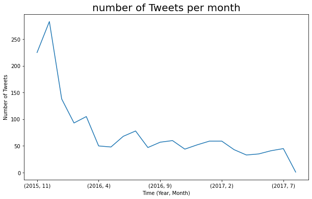

[figure not shown]

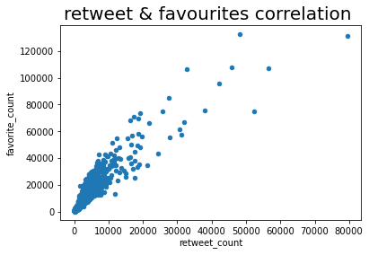

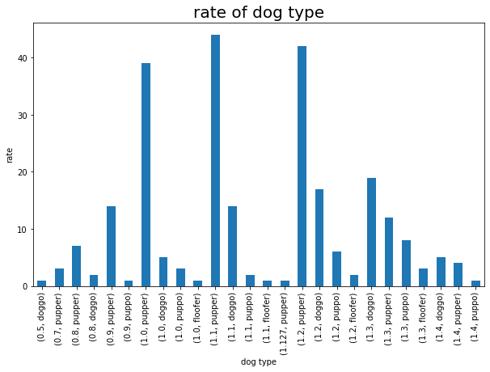

And we can also insoect the rate of each dog type accross the years

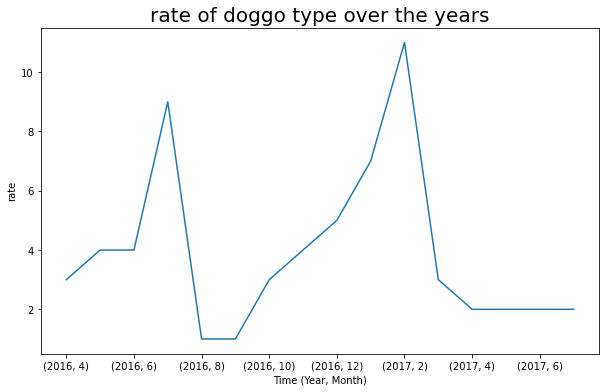

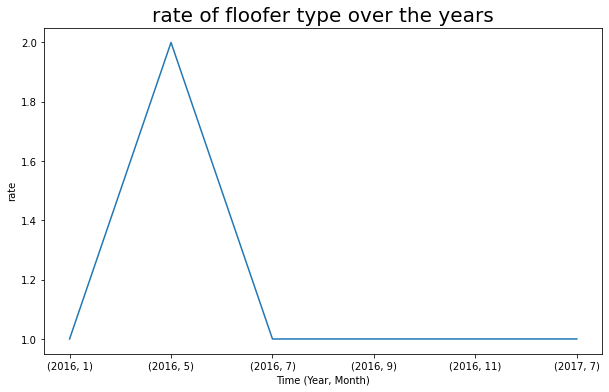

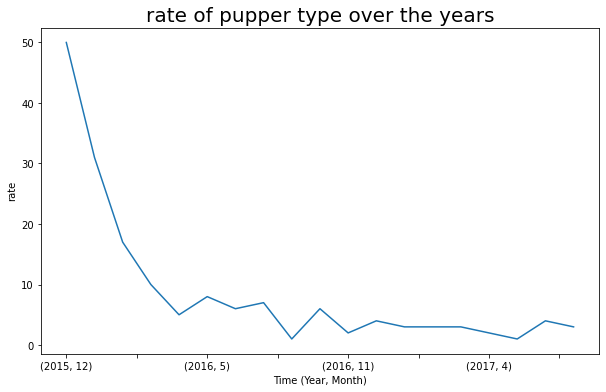

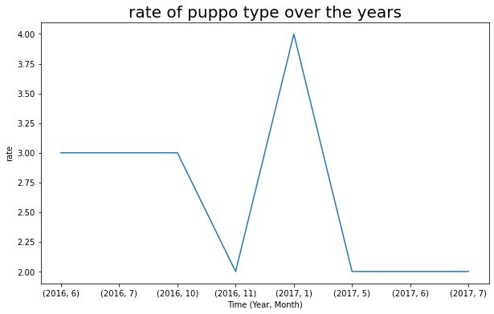

# conclusion

- Data wrangling is a mandatory skill for who is working on data analysis.
- Data cleanup implementation is not the hard thing but assessment and problem definition is the core of your analysis
- It's a critical important skill to understand the data carefully to be able to pritorize what should be kept and what should be ignored
- It's valuable to know how to represent the data in useful form for the business sides as it's a tricky way of profit
- Data can be gathered programatically from different resources
- use the power of programming to inspect the data (.head,sample,describe and so on)
- notice the issues from some calculation and investigation and that's the most tricky
- clean up is a very straight forward if you analyzed the issues (applied with pandas and numpy)
- combine all cleaned pieces together and store them for further analysis
- start analysis and visualization using visualization packages (matplotlib only used here)